# Assignment 2 - Steve Cheney

2024-04-16

## Question 1

```r
#### Set up looping numbers ####
################################
max.sample.size <- 20
n.sim <- 1000 # number of re-samplings we are going to run for each sample size

#### Set up matrices to save data. I have set up the first matrix for you ####
##############################################################################
sd.ori <- matrix(0, nrow = n.sim, ncol = max.sample.size)
# You will need to make two additional matrices:
# similar matrix for 1/sqrt(n) in an object called sd.n
sd.n <- matrix(0, nrow = n.sim, ncol = max.sample.size)
# similar matrix for 1/sqrt(n-2) in an object called sd.n.2
sd.n.2 <- matrix(0, nrow = n.sim, ncol = max.sample.size)


#### perform computations in a loop ####
########################################
for (sample.size in 2:max.sample.size) {
   for (i.sim in 1:n.sim) { # resample n.sim times. In each iteration:
      # Random sample of sample.size
      sample <- rnorm(n = sample.size, mean = 0, sd =1)
      # 'Classical' sd
      sd.ori.x <- sd(sample)
      # Store into sd.ori matrix
      sd.ori[i.sim, sample.size] <- sd.ori.x

      # next, calculate the first modified sd estimator for the same sample and save it where it belongs in sd.n
      sd.n.x <- sd.ori.x * sqrt(sample.size - 1) / sqrt(sample.size)
      sd.n[i.sim, sample.size] <- sd.n.x

      # next, calculate the second modified sd estimator for the same sample and save it where it belongs in sd.n.2
      if (sample.size > 2) { # avoid div/0
        sd.n.2.x <- sd.ori.x * sqrt(sample.size - 1) / sqrt(sample.size - 2)
        sd.n.2[i.sim, sample.size] <- sd.n.2.x
      }
   }
}

print(head(sd.ori))
```

```
##      [,1]       [,2]      [,3]      [,4]      [,5]      [,6]      [,7]
## [1,]    0 1.04879794 0.7658006 0.6750207 1.0477481 1.4019781 0.9206645
## [2,]    0 0.14095413 0.8440858 1.2700222 0.3975864 0.6667615 1.0414046
## [3,]    0 1.10622720 0.6888807 0.5628794 0.5867260 0.7878142 1.0441450
## [4,]    0 0.02250747 0.4504719 0.4698614 1.1244683 1.5088924 1.0576321
## [5,]    0 1.62101706 0.5836338 0.6479125 0.9503684 0.8906935 0.7853523
## [6,]    0 1.57284073 0.8380948 0.6673243 0.8951151 0.7014814 1.0432588
##           [,8]      [,9]     [,10]     [,11]     [,12]     [,13]     [,14]
## [1,] 1.0883155 1.2088292 0.9259634 1.1820158 1.1751433 1.2013634 1.0186679
## [2,] 1.4431747 0.9166872 1.1453776 0.9425521 0.7403842 1.3381122 0.9188643
## [3,] 1.0893501 0.8787677 0.8031669 0.9531078 0.7778830 0.8940841 0.7173560
## [4,] 0.5858454 1.0676492 0.6878153 0.9392441 1.0992281 0.9214444 1.0639907
## [5,] 1.2794685 0.7222026 1.3690613 1.0260508 0.8531810 1.1666872 1.0240173
## [6,] 0.9376053 1.1858670 1.2217620 0.9172345 0.8949861 0.9486500 0.9846632
##          [,15]     [,16]     [,17]     [,18]     [,19]     [,20]
## [1,] 1.0225177 0.9709267 1.0155316 0.9241892 1.0118791 1.0052513
## [2,] 1.0688842 0.8470737 1.0088745 1.0356511 0.8127172 0.8391086
## [3,] 0.9390787 0.9730878 0.9164410 1.0595087 1.1508655 0.6600202
## [4,] 0.7703961 0.7711492 0.8636678 1.0249909 0.7165760 0.9875591
## [5,] 1.0497648 0.7358030 0.7774974 1.1890748 0.6362204 0.6382047
## [6,] 1.1336867 1.0991511 0.8506499 0.9715748 0.9918999 1.0856548
```

```r
print(head(sd.n))
```

```
##      [,1]       [,2]      [,3]      [,4]      [,5]      [,6]      [,7]
## [1,]    0 0.74161214 0.6252735 0.5845851 0.9371344 1.2798251 0.8523697
## [2,]    0 0.09966962 0.6891932 1.0998714 0.3556120 0.6086672 0.9641533
## [3,]    0 0.78222076 0.5624688 0.4874678 0.5247837 0.7191727 0.9666904
## [4,]    0 0.01591519 0.3678087 0.4069119 1.0057550 1.3774240 0.9791770
## [5,]    0 1.14623215 0.4765350 0.5611087 0.8500354 0.8130882 0.7270950
## [6,]    0 1.11216635 0.6843016 0.5779198 0.8006153 0.6403620 0.9658700
##           [,8]      [,9]     [,10]     [,11]     [,12]     [,13]     [,14]
## [1,] 1.0180259 1.1396951 0.8784460 1.1270079 1.1251140 1.1542326 0.9816130
## [2,] 1.3499663 0.8642610 1.0866006 0.8986882 0.7088639 1.2856166 0.8854398
## [3,] 1.0189937 0.8285101 0.7619510 0.9087527 0.7447663 0.8590083 0.6912615
## [4,] 0.5480082 1.0065894 0.6525189 0.8955341 1.0524307 0.8852952 1.0252871
## [5,] 1.1968331 0.6808991 1.2988056 0.9783011 0.8168586 1.1209168 0.9867678
## [6,] 0.8770495 1.1180461 1.1590652 0.8745488 0.8568839 0.9114334 0.9488452
##          [,15]     [,16]     [,17]     [,18]     [,19]     [,20]
## [1,] 0.9878459 0.9400957 0.9852103 0.8981505 0.9848908 0.9797978
## [2,] 1.0326402 0.8201756 0.9787520 1.0064719 0.7910409 0.8178619
## [3,] 0.9072362 0.9421882 0.8890783 1.0296573 1.1201702 0.6433081
## [4,] 0.7442733 0.7466620 0.8378808 0.9961121 0.6974639 0.9625536
## [5,] 1.0141692 0.7124382 0.7542832 1.1555730 0.6192515 0.6220450
## [6,] 1.0952454 1.0642485 0.8252517 0.9442010 0.9654445 1.0581654
```

```r
print(head(sd.n.2))
```

```
##      [,1] [,2]      [,3]      [,4]      [,5]      [,6]      [,7]      [,8]
## [1,]    0    0 1.0830055 0.8267281 1.2098353 1.5674592 1.0085375 1.1755151
## [2,]    0    0 1.1937176 1.5554531 0.4590932 0.7454620 1.1408016 1.5588068
## [3,]    0    0 0.9742245 0.6893836 0.6774929 0.8808031 1.1438035 1.1766326
## [4,]    0    0 0.6370634 0.5754604 1.2984241 1.6869930 1.1585779 0.6327854
## [5,]    0    0 0.8253828 0.7935275 1.0973909 0.9958256 0.8603104 1.3819839
## [6,]    0    0 1.1852451 0.8173020 1.0335899 0.7842801 1.1428328 1.0127295
##           [,9]     [,10]     [,11]     [,12]     [,13]     [,14]     [,15]
## [1,] 1.2922928 0.9821325 1.2459541 1.2325007 1.2547831 1.0602632 1.0611167
## [2,] 0.9799799 1.2148564 0.9935372 0.7765215 1.3976126 0.9563843 1.1092336
## [3,] 0.9394421 0.8518872 1.0046639 0.8158506 0.9338404 0.7466478 0.9745280
## [4,] 1.1413650 0.7295383 0.9900502 1.1528801 0.9624173 1.1074366 0.7994778
## [5,] 0.7720670 1.4521088 1.0815525 0.8948238 1.2185650 1.0658310 1.0893924
## [6,] 1.2677452 1.2958742 0.9668501 0.9386693 0.9908326 1.0248700 1.1764823
##          [,16]     [,17]     [,18]     [,19]     [,20]
## [1,] 1.0050046 1.0488365 0.9526324 1.0412150 1.0327975
## [2,] 0.8768046 1.0419611 1.0675247 0.8362791 0.8621021
## [3,] 1.0072416 0.9464962 1.0921165 1.1842308 0.6781063
## [4,] 0.7982152 0.8919923 1.0565364 0.7373507 1.0146206
## [5,] 0.7616284 0.8029958 1.2256703 0.6546654 0.6556930
## [6,] 1.1377295 0.8785475 1.0014764 1.0206566 1.1154043
```

```r
#### Once all ad's are calculated, look at the sample statistics for their distributions. ####
##############################################################################################
# for each sample size (i.e. for each column of sd.ori) calculate the mean of
# "classical" sd’s across all resampled samples of that size as well as their standard deviations
mean.sd.ori <- apply(sd.ori, 2, mean)
sd.sd.ori <- apply(sd.ori, 2, sd)
# Print data
print(data.frame(mean.sd.ori, sd.sd.ori))
```

```
##    mean.sd.ori sd.sd.ori
## 1    0.0000000 0.0000000
## 2    0.7977186 0.5973041
## 3    0.8796449 0.4536902
## 4    0.9220168 0.3874732
## 5    0.9672365 0.3506531
## 6    0.9594827 0.3052473
## 7    0.9621327 0.2720932
## 8    0.9763905 0.2626425
## 9    0.9777144 0.2481920
## 10   0.9711510 0.2366748
## 11   0.9649913 0.2167845
## 12   0.9855358 0.2057321
## 13   0.9693132 0.2000679
## 14   0.9794540 0.2029323
## 15   0.9927298 0.1920227
## 16   0.9850593 0.1848673
## 17   0.9893209 0.1861830
## 18   0.9870152 0.1737067
## 19   0.9928827 0.1693847
## 20   0.9921958 0.1651027
```

```r
# Then do the same for estimators with sqrt(n) and sqrt(n-2) in denominators.
mean.sd.n <- apply(sd.n, 2, mean)
sd.sd.n <- apply(sd.n, 2, sd)
mean.sd.n.2 <- apply(sd.n.2, 2, mean)
sd.sd.n.2 <- apply(sd.n.2, 2, sd)
# Print data
print(data.frame(mean.sd.n, sd.sd.n))
```

```
##    mean.sd.n   sd.sd.n
## 1  0.0000000 0.0000000
## 2  0.5640722 0.4223578
## 3  0.7182271 0.3704365
## 4  0.7984900 0.3355617
## 5  0.8651226 0.3136337
## 6  0.8758838 0.2786514
## 7  0.8907618 0.2519094
## 8  0.9133296 0.2456795
## 9  0.9217980 0.2339977
## 10 0.9213147 0.2245294
## 11 0.9200831 0.2066959
## 12 0.9435787 0.1969735
## 13 0.9312860 0.1922190
## 14 0.9438255 0.1955504
## 15 0.9590681 0.1855116
## 16 0.9537795 0.1789970
## 17 0.9597822 0.1806240
## 18 0.9592064 0.1688126
## 19 0.9664011 0.1648669
## 20 0.9670728 0.1609222
```

```r
print(data.frame(mean.sd.n.2, sd.sd.n.2))
```

```
##    mean.sd.n.2 sd.sd.n.2
## 1     0.000000 0.0000000
## 2     0.000000 0.0000000
## 3     1.244006 0.6416148
## 4     1.129235 0.4745558
## 5     1.116868 0.4048993
## 6     1.072734 0.3412769
## 7     1.053964 0.2980632
## 8     1.054622 0.2836863
## 9     1.045221 0.2653284
## 10    1.030061 0.2510315
## 11    1.017190 0.2285109
## 12    1.033639 0.2157736
## 13    1.012415 0.2089641
## 14    1.019448 0.2112186
## 15    1.030204 0.1992714
## 16    1.019633 0.1913559
## 17    1.021766 0.1922890
## 18    1.017392 0.1790528
## 19    1.021668 0.1742954
## 20    1.019384 0.1696269
```

```r
full.df <- data.frame(mean.sd.ori,sd.sd.ori,mean.sd.n,sd.sd.n,mean.sd.n.2,sd.sd.n.2)
```

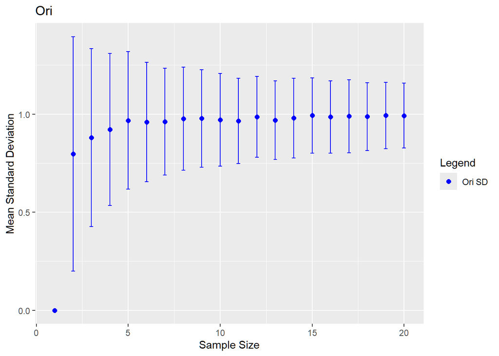

```r
# Load ggplot2
if (!require('ggplot2')) install.packages('ggplot2', dependencies = TRUE)
library(ggplot2)

full.df$sample.size <- 1:max.sample.size

# ggplot for ori
plot.ori <- ggplot(full.df, aes(x = sample.size)) +
  geom_point(aes(y = mean.sd.ori, color = "blue"), size = 2) +
  geom_errorbar(aes(ymin = mean.sd.ori - sd.sd.ori, ymax = mean.sd.ori + sd.sd.ori),
                width = 0.2, color = "blue") +
  labs(title = "Ori",
       x = "Sample Size",
       y = "Mean Standard Deviation") +
  scale_color_manual("Legend", values = c("blue" = "blue"), labels = c("Ori SD"))


# ggplot for n
plot.n <- ggplot(full.df, aes(x = sample.size)) +
  geom_point(aes(y = mean.sd.n, color = "red"), size = 2) +
  geom_errorbar(aes(ymin = mean.sd.n - sd.sd.n, ymax = mean.sd.n + sd.sd.n),
                width = 0.2, color = "red") +
  labs(title = "n",
       x = "Sample Size",
       y = "Mean Standard Deviation") +
  scale_color_manual("Legend", values = c("red" = "red"), labels = c("n SD"))


# ggplot for n.2
plot.n.2 <- ggplot(full.df, aes(x = sample.size)) +
  geom_point(aes(y = mean.sd.n.2, color = "green"), size = 2) +
  geom_errorbar(aes(ymin = mean.sd.n.2 - sd.sd.n.2, ymax = mean.sd.n.2 + sd.sd.n.2),
                width = 0.2, color = "green") +
  labs(title = "n.2",
       x = "Sample Size",
       y = "Mean Standard Deviation") +
  scale_color_manual("Legend", values = c("green" = "green"), labels = c("n.2 SD"))

plot.ori
```

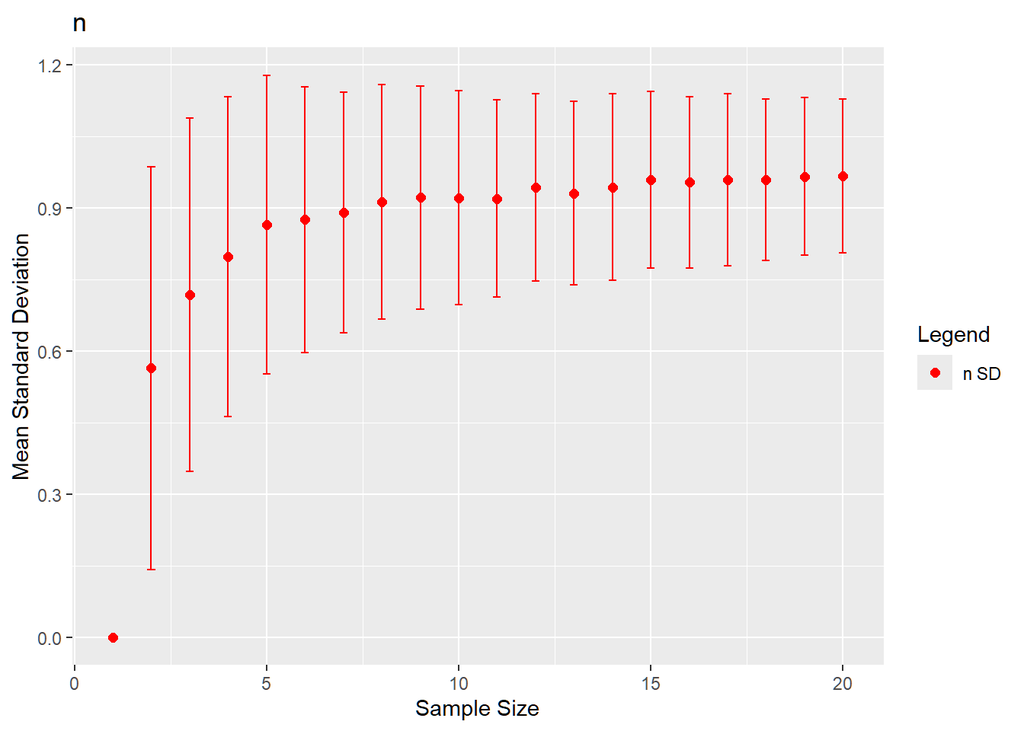

```r
plot.n
```

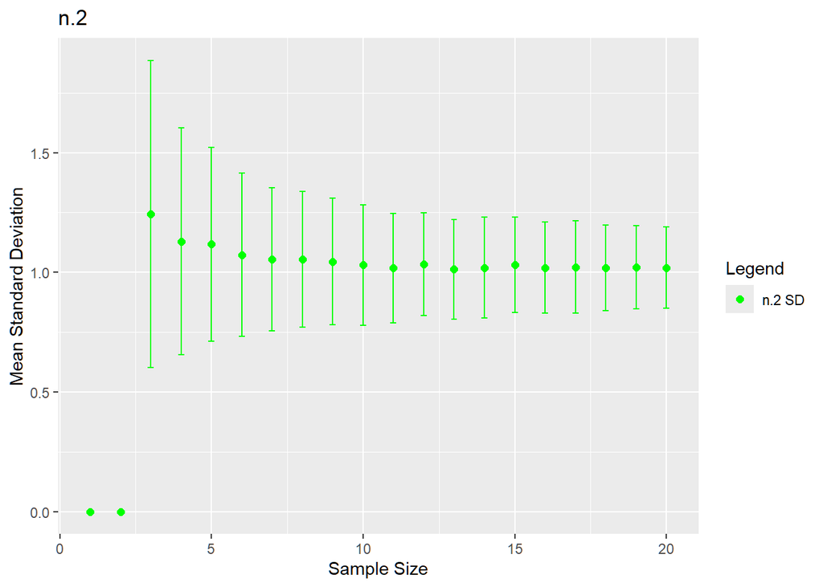

```r
plot.n.2
```

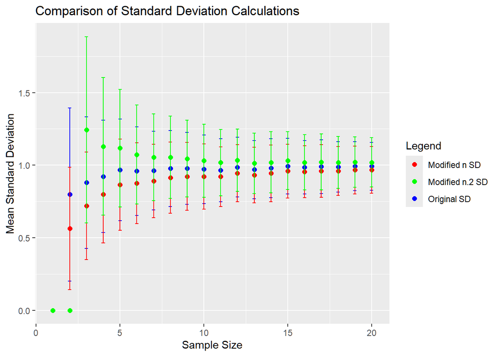

```r
# Combined plot
combined_plot <- ggplot(full.df, aes(x = sample.size)) +
  # Adding points and error bars for 'Ori' SD
  geom_point(aes(y = mean.sd.ori, color = "Ori SD"), size = 2) +
  geom_errorbar(aes(ymin = mean.sd.ori - sd.sd.ori, ymax = mean.sd.ori + sd.sd.ori),
                width = 0.2, color = "blue") +

  # Adding points and error bars for 'n' SD
  geom_point(aes(y = mean.sd.n, color = "n SD"), size = 2) +
  geom_errorbar(aes(ymin = mean.sd.n - sd.sd.n, ymax = mean.sd.n + sd.sd.n),
                width = 0.2, color = "red") +

  # Adding points and error bars for 'n.2' SD
  geom_point(aes(y = mean.sd.n.2, color = "n.2 SD"), size = 2) +
  geom_errorbar(aes(ymin = mean.sd.n.2 - sd.sd.n.2, ymax = mean.sd.n.2 + sd.sd.n.2),
                width = 0.2, color = "green") +

  # Setting up legend and labels
  scale_color_manual("Legend",
                     values = c("Ori SD" = "blue", "n SD" = "red", "n.2 SD" = "green"),
                     labels = c("Ori SD" = "Original SD", "n SD" = "Modified n SD", "n.2 SD" = "Modified n.2 SD")) +
  labs(title = "Comparison of Standard Deviation Calculations",
       x = "Sample Size",
       y = "Mean Standard Deviation")

combined_plot
```

We can see here how all of our plots converge to 1, which is the standard deviation of the original sample. Our points are essentially adding in random data through their sampling, so it adjusts the MSD across each sample size. However, as our sample size gets larger, and the randomness essentially becomes more normalized due to less variation in randomness with a larger n, we get our convergence.

## Question 2

```r
#### Step 1: create a matrix containing the resamplings (10,000 rows for the simulations and 12 columns for the resamplings).

mean <- 2
variance <- 3
sd <- sqrt(variance)

n1 <- 5 # Sample size 1
n2 <- 7 # Sample size 2

# Generate samples

num.simulations <- 10000

# Initialize a matrix to store resampling results
resample.matrix <- matrix(NA, nrow = num.simulations, ncol = n1 + n2)

# Set seed for reproducibility
set.seed(505)

# Populate the resample matrix
for (i in 1:num.simulations) {
    sample1 <- rnorm(n1, mean, sd)
    sample2 <- rnorm(n2, mean, sd)
    resample.matrix[i, ] <- c(sample1, sample2)
}

#### Step 2: define a function that will calculate the difference between the means of sample 1 and sample 2 in our representation of the data
mean.diff <- function(x) {
  mean.sample1 <- mean(x[1:n1])  # Calc mean to n1
  mean.sample2 <- mean(x[(n1 + 1):(n1 + n2)])  # Calc mean to next n2
  mean.diff <- mean.sample1 - mean.sample2
  return(mean.diff)
}

#### Step 3: calculate the difference in the means. for all rows of your matrix. Save it in an object called sim.diff.

# Do ttests of the pvals
t_test_p_value <- function(row) {
  t.sample1 <- row[1:n1]
  t.sample2 <- row[(n1 + 1):(n1 + n2)]
  test <- t.test(t.sample1, t.sample2)  # Perform t-test
  return(test$p.value)  # Return the p-value of the t-test
}
# Apply the function to each row of the resample.matrix
t_test_p_values <- apply(resample.matrix, 1, t_test_p_value)
#t_test_p_values

sim.diff <- apply(resample.matrix, 1, mean.diff)
#sim.diff

#### Step 4: calculate the brute force p-value by taking the rank of the negative absolute value of sim.diff divided by the length of sim.diff. Save this in a vector called sim.p.rk

# abs(diffs)
abs_diff <- abs(sim.diff)

# Ranks of - abs
ranks <- rank(-abs_diff)

# Get p-values
sim.p.rk <- ranks / num.simulations
```

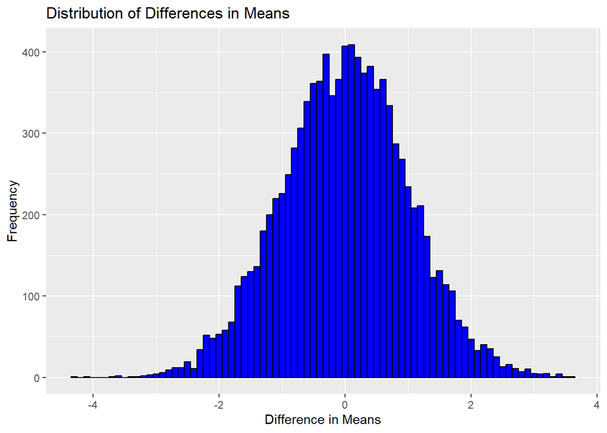

```r
ggplot(data = data.frame(Difference = sim.diff), aes(x = Difference)) +
  geom_histogram(binwidth = 0.1, fill = "blue", color = "black") +
  ggtitle("Distribution of Differences in Means") +
  xlab("Difference in Means") + ylab("Frequency")
```

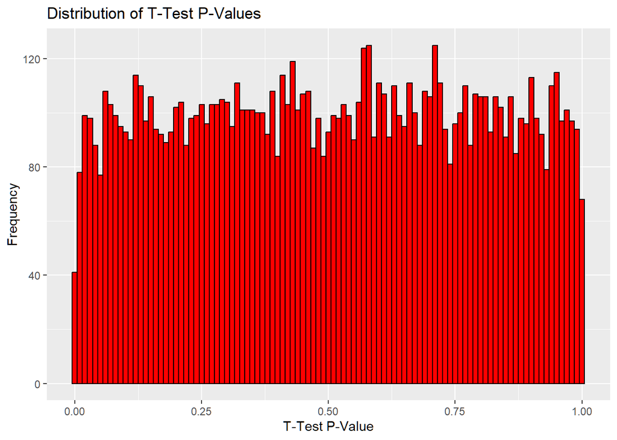

```r
ggplot(data = data.frame(TTestPValues = t_test_p_values), aes(x = TTestPValues)) +
  geom_histogram(binwidth = 0.01, fill = "red", color = "black") +
  ggtitle("Distribution of T-Test P-Values") +
  xlab("T-Test P-Value") + ylab("Frequency")
```

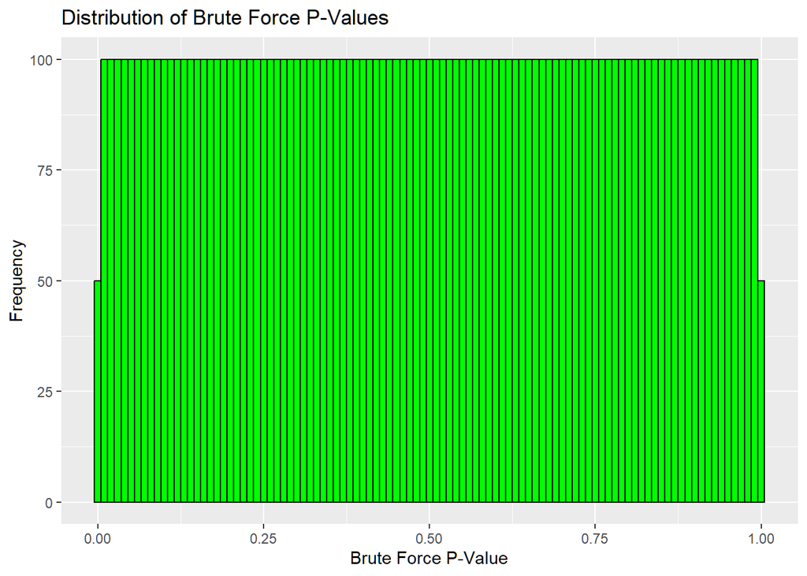

```r
ggplot(data = data.frame(BruteForcePValues = sim.p.rk), aes(x = BruteForcePValues)) +
  geom_histogram(binwidth = 0.01, fill = "green", color = "black") +
  ggtitle("Distribution of Brute Force P-Values") +
  xlab("Brute Force P-Value") + ylab("Frequency")
```

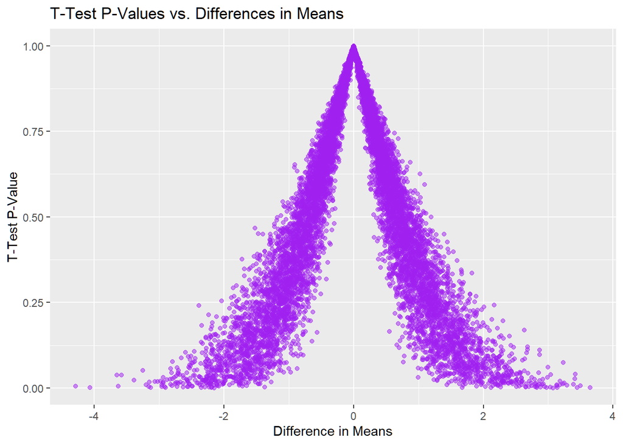

```r
ggplot(data = data.frame(Difference = sim.diff, TTestPValues = t_test_p_values), aes(x = Difference, y = TTestPValues)) +
  geom_point(alpha = 0.5, color = "purple") +
  ggtitle("T-Test P-Values vs. Differences in Means") +
  xlab("Difference in Means") + ylab("T-Test P-Value")
```

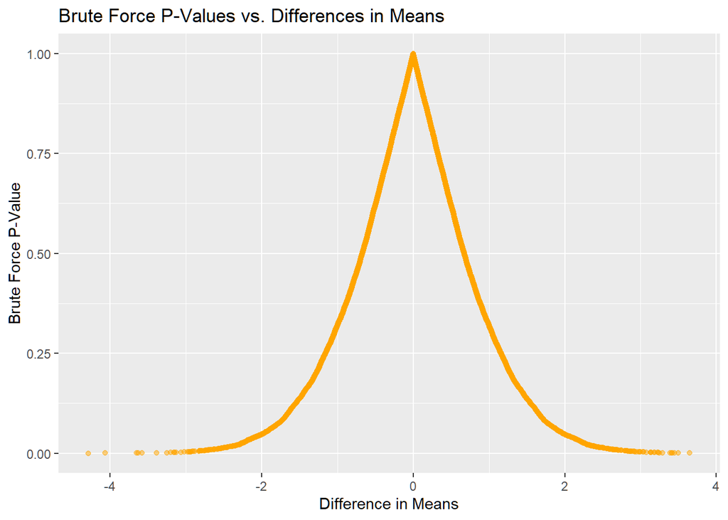

```r
ggplot(data = data.frame(Difference = sim.diff, BruteForcePValues = sim.p.rk), aes(x = Difference, y = BruteForcePValues)) +
  geom_point(alpha = 0.5, color = "orange") +
  ggtitle("Brute Force P-Values vs. Differences in Means") +
  xlab("Difference in Means") + ylab("Brute Force P-Value")
```

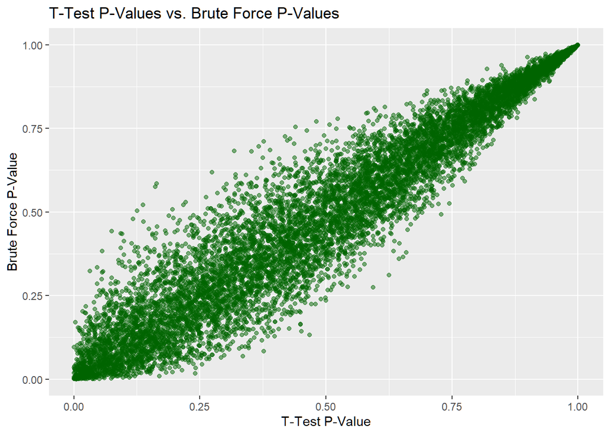

```r
ggplot(data = data.frame(TTestPValues = t_test_p_values, BruteForcePValues = sim.p.rk), aes(x = TTestPValues, y = BruteForcePValues)) +
  geom_point(alpha = 0.5, color = "darkgreen") +
  ggtitle("T-Test P-Values vs. Brute Force P-Values") +
  xlab("T-Test P-Value") + ylab("Brute Force P-Value")
```

Our results here show a clear trend with some statistical variance regarding our p-values. Brute forcing our values will tend to get a more uniform approach.Brute-force p-values typically exhibit less variance than those obtained from t-tests because they are based on the empirical distribution of the data, which makes them resistant to violations of the t-test’s assumptions about normality and equal variances. By utilizing ranking methods, brute-force approaches mitigate the influence of outliers and non-normal distributions, offering a more stable estimation of the significance level across different simulations. This is especially clear in this first set of samples because of the relatively small sample size. We’ll see the difference when these increase in just a moment:

### Repeating with new sample sizes

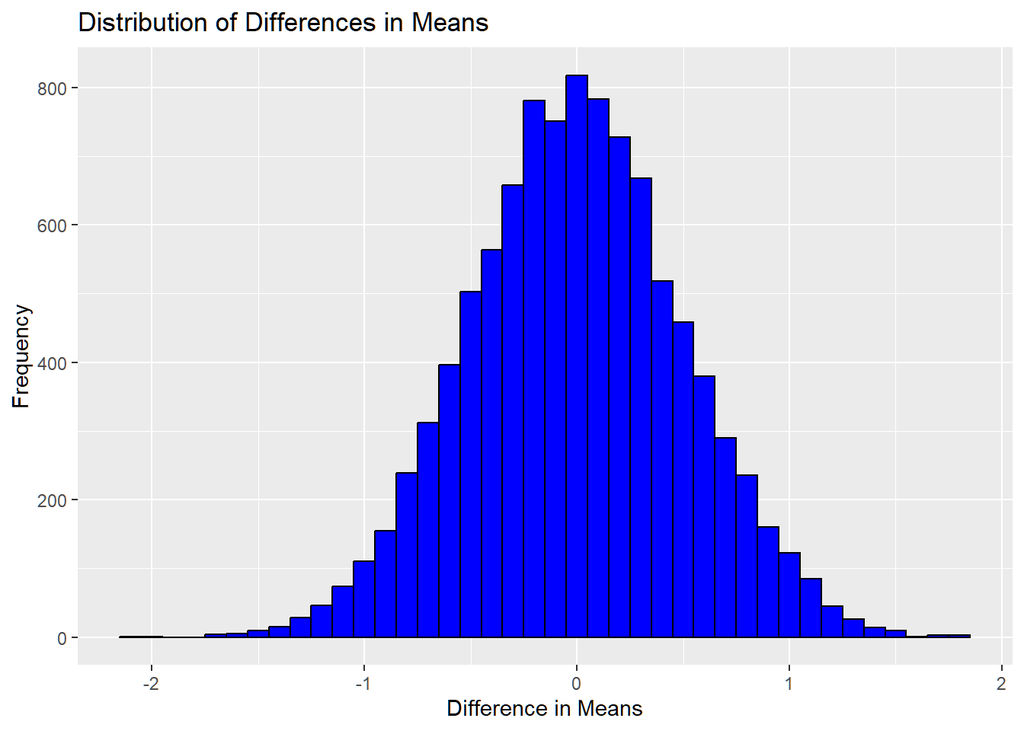

```r
mean <- 2
variance <- 3
sd <- sqrt(variance)
n1 <- 20
n2 <- 28
num.simulations <- 10000
resample.matrix <- matrix(NA, nrow = num.simulations, ncol = n1 + n2)
set.seed(505)
for (i in 1:num.simulations) {
    sample1 <- rnorm(n1, mean, sd)
    sample2 <- rnorm(n2, mean, sd)
    resample.matrix[i, ] <- c(sample1, sample2)
}
mean.diff <- function(x) {
  mean.sample1 <- mean(x[1:n1])
  mean.sample2 <- mean(x[(n1 + 1):(n1 + n2)])
  mean.diff <- mean.sample1 - mean.sample2
  return(mean.diff)
}
t_test_p_value <- function(row) {
  t.sample1 <- row[1:n1]
  t.sample2 <- row[(n1 + 1):(n1 + n2)]
  test <- t.test(t.sample1, t.sample2)
  return(test$p.value)
}
t_test_p_values <- apply(resample.matrix, 1, t_test_p_value)
sim.diff <- apply(resample.matrix, 1, mean.diff)
abs_diff <- abs(sim.diff)
ranks <- rank(-abs_diff)
sim.p.rk <- ranks / num.simulations

ggplot(data = data.frame(Difference = sim.diff), aes(x = Difference)) +
  geom_histogram(binwidth = 0.1, fill = "blue", color = "black") +
  ggtitle("Distribution of Differences in Means") +
  xlab("Difference in Means") + ylab("Frequency")
```

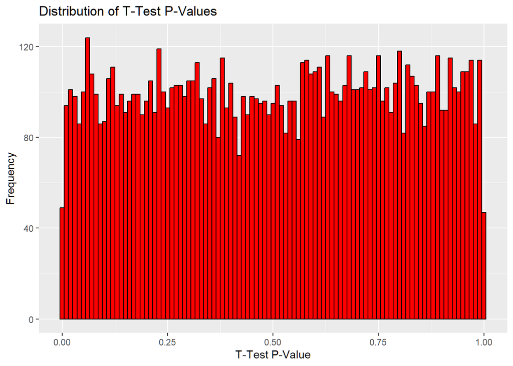

```r
ggplot(data = data.frame(TTestPValues = t_test_p_values), aes(x = TTestPValues)) +
  geom_histogram(binwidth = 0.01, fill = "red", color = "black") +
  ggtitle("Distribution of T-Test P-Values") +
  xlab("T-Test P-Value") + ylab("Frequency")
```

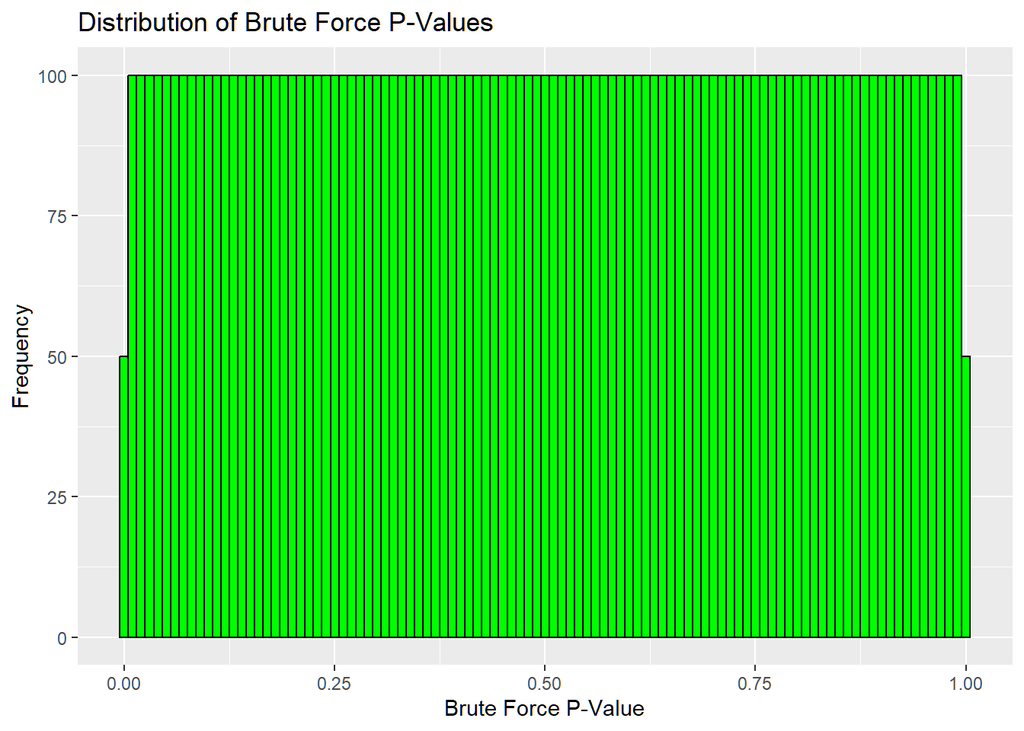

```r
ggplot(data = data.frame(BruteForcePValues = sim.p.rk), aes(x = BruteForcePValues)) +
  geom_histogram(binwidth = 0.01, fill = "green", color = "black") +
  ggtitle("Distribution of Brute Force P-Values") +
  xlab("Brute Force P-Value") + ylab("Frequency")
```

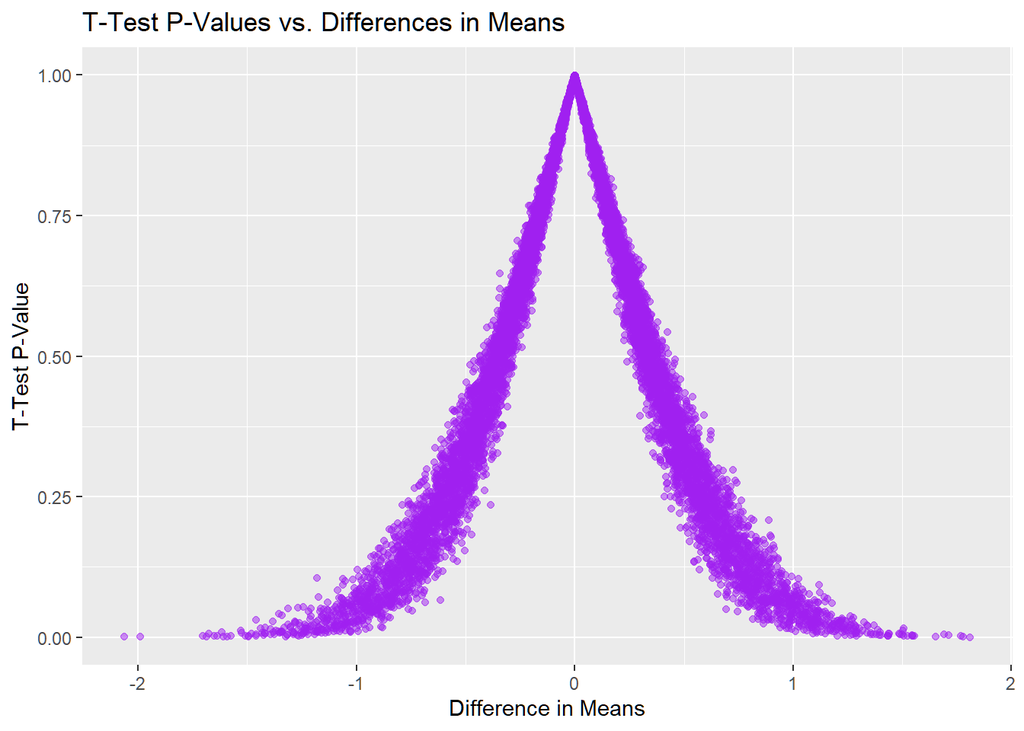

```r
ggplot(data = data.frame(Difference = sim.diff, TTestPValues = t_test_p_values), aes(x = Difference, y = TTestPValues)) +
  geom_point(alpha = 0.5, color = "purple") +
  ggtitle("T-Test P-Values vs. Differences in Means") +
  xlab("Difference in Means") + ylab("T-Test P-Value")
```

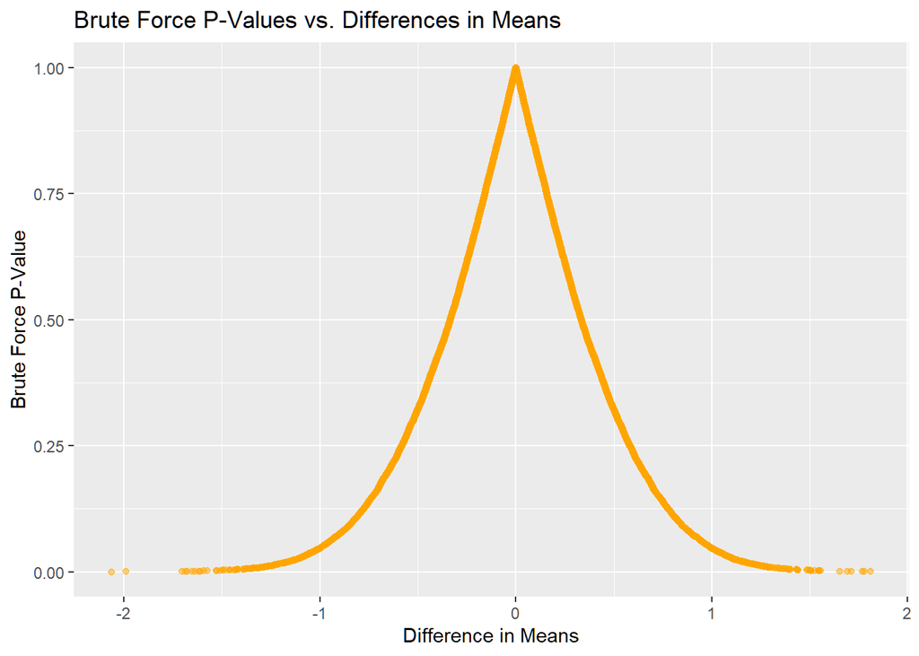

```r
ggplot(data = data.frame(Difference = sim.diff, BruteForcePValues = sim.p.rk), aes(x = Difference, y = BruteForcePValues)) +
  geom_point(alpha = 0.5, color = "orange") +
  ggtitle("Brute Force P-Values vs. Differences in Means") +
  xlab("Difference in Means") + ylab("Brute Force P-Value")
```

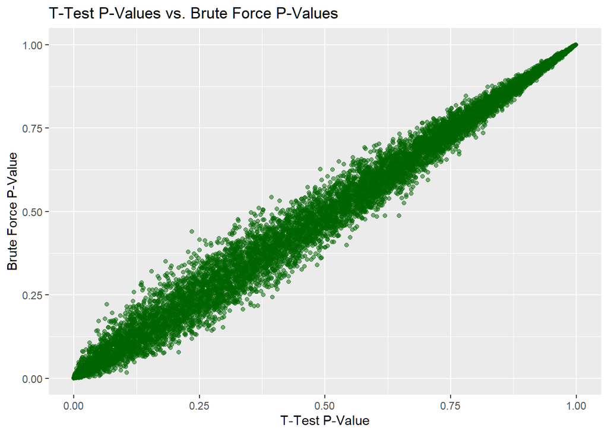

```r
ggplot(data = data.frame(TTestPValues = t_test_p_values, BruteForcePValues = sim.p.rk), aes(x = TTestPValues, y = BruteForcePValues)) +
  geom_point(alpha = 0.5, color = "darkgreen") +
  ggtitle("T-Test P-Values vs. Brute Force P-Values") +
  xlab("T-Test P-Value") + ylab("Brute Force P-Value")
```

As sample size increases, the variance of the estimate decreases due to the Central Limit Theorem, which states that the distribution of the sample mean will approximate a normal distribution as the sample size grows, regardless of the original data’s distribution. This reduction in variance leads to more precise estimates, narrowing the confidence intervals and making simulated results more closely align with theoretically calculated probabilities. This is very evident in our second set of plots, specifically with the ranked p value and t test p value plot at the end, where there is a tighter plot of data points.

## Question 3

### a

```r
set.seed(123)
n1 <- 423
mean1 <- 67
sd1 <- 11
sample1 <- rnorm(n1, mean = mean1, sd = sd1)

n2 <- 423
sample2 <- c(rnorm(n2/2, mean = 10, sd = 1), rnorm(n2/2, mean = -10, sd = 1))


ttest.res <- t.test(sample1, sample2)
print(ttest.res$p.value) # pval
```

```
## [1] 0
```

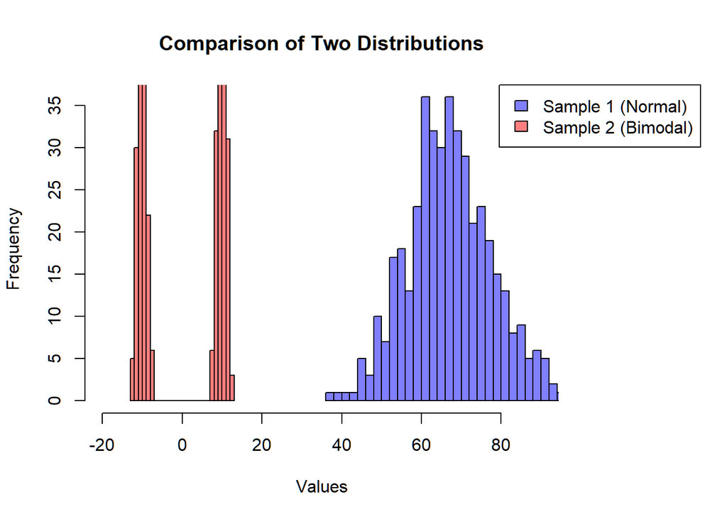

```r
par(mar = c(5, 4, 4, 8) + 0.1)
hist(sample1, breaks = 30, col = rgb(0, 0, 1, 0.5), main = "Comparison of Two Distributions", xlab = "Values", xlim = c(-20, 90))
hist(sample2, breaks = 30, col = rgb(1, 0, 0, 0.5), add = TRUE)
legend("topright", inset=c(-0.3,0), legend = c("Sample 1 (Normal)", "Sample 2 (Bimodal)"),
       fill = c(rgb(0, 0, 1, 0.5), rgb(1, 0, 0, 0.5)), xpd=TRUE, horiz=FALSE)
```

### b

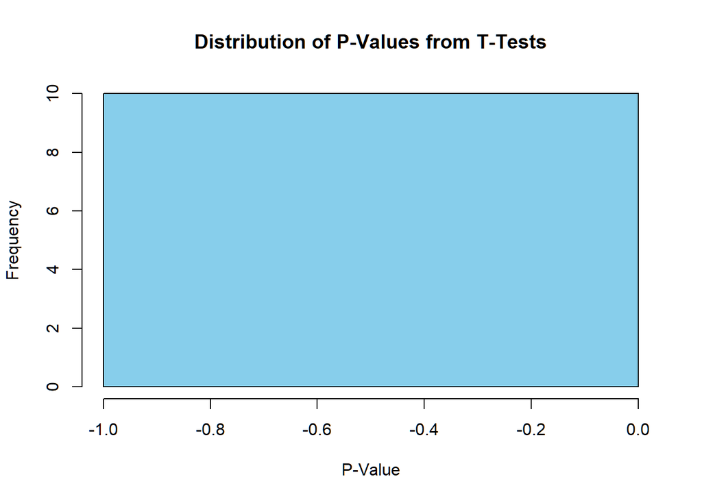

```r
set.seed(123)
n1 <- 423
mean1 <- 67
sd1 <- 11
sample1 <- rnorm(n1, mean = mean1, sd = sd1)

# Parameters for Sample 2, defining these outside the loop to use inside it
n2 <- 423
mean2_pos <- 10  # Define positive mean for half of sample2
mean2_neg <- -10  # Define negative mean for the other half of sample2
sd2 <- 1  # Standard deviation for sample2

# Number of trials
num_trials <- 10

# Vector to store p-values
p_values <- numeric(num_trials)

for (i in 1:num_trials) {
  # Pick samples
  sample1 <- rnorm(n1, mean = mean1, sd = sd1)
  sample2 <- c(rnorm(n2/2, mean = mean2_pos, sd = sd2), rnorm(n2/2, mean = mean2_neg, sd = sd2))

  # t-test and store p-value
  ttest_res <- t.test(sample1, sample2)
  p_values[i] <- ttest_res$p.value
}

# Plot
hist(p_values, breaks = 50, col = "skyblue", main = "Distribution of P-Values from T-Tests", xlab = "P-Value")
```